# Analysis of Person’s activity

**1.Loading and preprocessing of data**

```r
library(lattice)
#loading the data
myData<- read.csv("activity.csv")
#check the summary of data to see if any preprocessing has to be done
summary(myData)
```

```
##      steps                date          interval
##  Min.   :  0.00   2012-10-01:  288   Min.   :   0.0
##  1st Qu.:  0.00   2012-10-02:  288   1st Qu.: 588.8
##  Median :  0.00   2012-10-03:  288   Median :1177.5
##  Mean   : 37.38   2012-10-04:  288   Mean   :1177.5
##  3rd Qu.: 12.00   2012-10-05:  288   3rd Qu.:1766.2
##  Max.   :806.00   2012-10-06:  288   Max.   :2355.0
##  NA's   :2304     (Other)   :15840
```

From the summary, we can see that the **date** column has **15840** other values and **steps** column has **2304** NA values. Modify the Date column so that we get the actual date for each row.

```r
#preprocessing step
myData$date <- as.Date(myData$date,"%Y-%m-%d")
```

**2.What is mean total number of steps taken per day?**

```r
#seeing the column names of the dataset
names(myData)
```

```
## [1] "steps"    "date"     "interval"
```

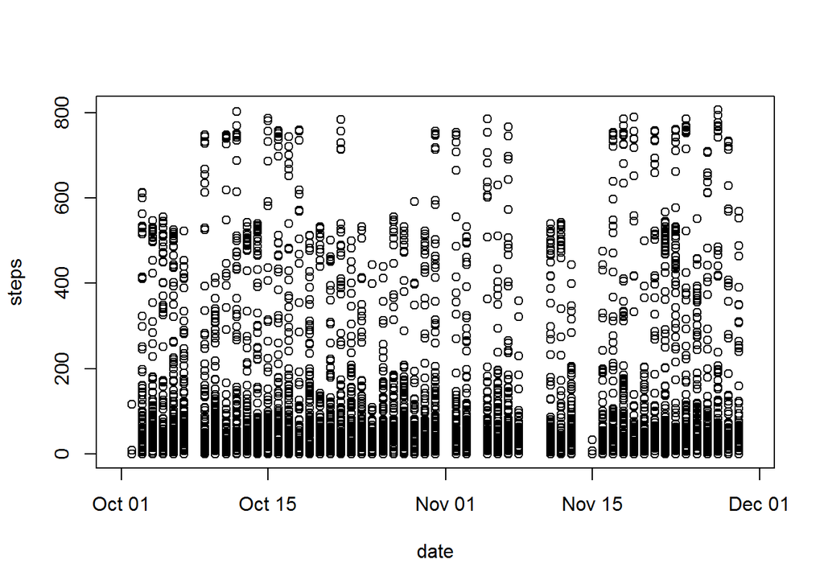

```r
#create a plot to see how the distribution is between number of steps taken on each day
plot(steps~date,myData)
```

```r
#tail(myData$date)
stepsByDay <- aggregate(steps~date,data=myData,sum,na.rm=TRUE)
#names(stepsByDay)
#plotting the histogram for the number of steps taken
dev.copy(png,"./figures/plot1.png",width=480,height=480)
```

```r
hist(stepsByDay$steps,xlab="Day",ylab="steps taken",main="Mean num of steps taken by day",col="red")
dev.off()
```

[output not shown]

*calculating mean and median*

```r
mean(stepsByDay$steps)
```

```
## [1] 10766.19
```

```r
median(stepsByDay$steps)
```

```
## [1] 10765
```

**3.What is the average daily activity pattern?**

```r
names(myData)
```

```
## [1] "steps"    "date"     "interval"
```

```r
#see the mean number of steps taken in each interval
tmyData <- tapply(myData$steps, myData$interval, mean, na.rm = TRUE)
```

By using the tapply function we have modified the given data set such that each column name is equal to the interval. Using names() command we can see that each column is the interval. Each column value is equal to the mean number of steps taken in that interval.

```r
names(tmyData)
```

```
##   [1] "0"    "5"    "10"   "15"   "20"   "25"   "30"   "35"   "40"   "45"
##  [11] "50"   "55"   "100"  "105"  "110"  "115"  "120"  "125"  "130"  "135"
##  [21] "140"  "145"  "150"  "155"  "200"  "205"  "210"  "215"  "220"  "225"
##  [31] "230"  "235"  "240"  "245"  "250"  "255"  "300"  "305"  "310"  "315"
##  [41] "320"  "325"  "330"  "335"  "340"  "345"  "350"  "355"  "400"  "405"
##  [51] "410"  "415"  "420"  "425"  "430"  "435"  "440"  "445"  "450"  "455"
##  [61] "500"  "505"  "510"  "515"  "520"  "525"  "530"  "535"  "540"  "545"
##  [71] "550"  "555"  "600"  "605"  "610"  "615"  "620"  "625"  "630"  "635"
##  [81] "640"  "645"  "650"  "655"  "700"  "705"  "710"  "715"  "720"  "725"
##  [91] "730"  "735"  "740"  "745"  "750"  "755"  "800"  "805"  "810"  "815"
## [101] "820"  "825"  "830"  "835"  "840"  "845"  "850"  "855"  "900"  "905"
## [111] "910"  "915"  "920"  "925"  "930"  "935"  "940"  "945"  "950"  "955"
## [121] "1000" "1005" "1010" "1015" "1020" "1025" "1030" "1035" "1040" "1045"
## [131] "1050" "1055" "1100" "1105" "1110" "1115" "1120" "1125" "1130" "1135"
## [141] "1140" "1145" "1150" "1155" "1200" "1205" "1210" "1215" "1220" "1225"
## [151] "1230" "1235" "1240" "1245" "1250" "1255" "1300" "1305" "1310" "1315"
## [161] "1320" "1325" "1330" "1335" "1340" "1345" "1350" "1355" "1400" "1405"
## [171] "1410" "1415" "1420" "1425" "1430" "1435" "1440" "1445" "1450" "1455"
## [181] "1500" "1505" "1510" "1515" "1520" "1525" "1530" "1535" "1540" "1545"
## [191] "1550" "1555" "1600" "1605" "1610" "1615" "1620" "1625" "1630" "1635"
## [201] "1640" "1645" "1650" "1655" "1700" "1705" "1710" "1715" "1720" "1725"
## [211] "1730" "1735" "1740" "1745" "1750" "1755" "1800" "1805" "1810" "1815"
## [221] "1820" "1825" "1830" "1835" "1840" "1845" "1850" "1855" "1900" "1905"
## [231] "1910" "1915" "1920" "1925" "1930" "1935" "1940" "1945" "1950" "1955"
## [241] "2000" "2005" "2010" "2015" "2020" "2025" "2030" "2035" "2040" "2045"
## [251] "2050" "2055" "2100" "2105" "2110" "2115" "2120" "2125" "2130" "2135"
## [261] "2140" "2145" "2150" "2155" "2200" "2205" "2210" "2215" "2220" "2225"
## [271] "2230" "2235" "2240" "2245" "2250" "2255" "2300" "2305" "2310" "2315"
## [281] "2320" "2325" "2330" "2335" "2340" "2345" "2350" "2355"
```

```r
head(tmyData)
```

```
##         0         5        10        15        20        25
## 1.7169811 0.3396226 0.1320755 0.1509434 0.0754717 2.0943396
```

```r
dev.copy(png,"./figures/plot2.png",width=480,height=480)
```

```r
plot(names(tmyData),tmyData,type="l",xlab="5 minute interval",ylab="avg steps for each interval",main="average daily activity pattern",col="red")
dev.off()
```

[output not shown]

*maximum steps interval*

```r
max_interval <- which.max(tmyData)
names(max_interval)
```

```
## [1] "835"
```

**4.Inputting missing values**

```r
#counting number of missing values in data set
count <-sum(is.na(myData))
```

As specified in the instructions I am using the mean value of number of steps in a interval as the replacement for NA

```r
#replacing NA values with mean value for that interval
StepsAverage <- aggregate(steps~interval,data=myData,mean)
fillNA <- numeric()
for(i in 1:nrow(myData))
{
  r <-myData[i,]
  if(is.na(r$steps))
  {
    steps <- subset(StepsAverage,interval==r$interval)$steps
  }
  else
    steps <-r$steps
  fillNA <- c(fillNA,steps)
}
```

*Forming the new data set with replacing NA values*

```r
newData <- myData
newData$steps <- fillNA
head(myData)
```

```
##   steps       date interval
## 1    NA 2012-10-01        0
## 2    NA 2012-10-01        5
## 3    NA 2012-10-01       10
## 4    NA 2012-10-01       15
## 5    NA 2012-10-01       20
## 6    NA 2012-10-01       25
```

```r
head(newData)
```

```
##       steps       date interval
## 1 1.7169811 2012-10-01        0
## 2 0.3396226 2012-10-01        5
## 3 0.1320755 2012-10-01       10
## 4 0.1509434 2012-10-01       15
## 5 0.0754717 2012-10-01       20
## 6 2.0943396 2012-10-01       25
```

From the above two head() commands we can see the NA values in original dataset are replaced with the modified value in the newly created dataset.

```r
newTotalSteps <- aggregate(steps ~ date, data = newData, sum, na.rm = TRUE)
dev.copy(png,"./figures/plot3.png",width=480,height=480)
```

```r
hist(newTotalSteps$steps, main = "Total steps by day", xlab = "day", col = "blue")
dev.off()
```

[output not shown]

*calculating the median and mean for new dataset*

```r
mean(newTotalSteps$steps)
```

```
## [1] 10766.19
```

```r
median(newTotalSteps$steps)
```

```
## [1] 10766.19
```

**5.Are there differences in activity patterns between weekdays and weekends?**

```r
#checking and assigning if the day is weekday or weekend
dayType <- weekdays(myData$date)
levelOfDay <- vector()
for (i in 1:nrow(myData)) {
  if (dayType[i] == "Saturday" | dayType[i]=="Sunday") {
    levelOfDay[i] <- "Weekend"

  } else {
    levelOfDay[i] <- "Weekday"
  }
}
```

*adding one more column to the new Data set specifying if the date is weekend or weekday*

```r
names(newData)
```

```
## [1] "steps"    "date"     "interval"
```

```r
newData$levelOfDay <- levelOfDay
```

*converting level to factor variable*

```r
newData$levelOfDay <- factor(newData$levelOfDay)
stepsByEachDay <- aggregate(steps~interval+levelOfDay,data=newData,mean)
names(stepsByEachDay)
```

```
## [1] "interval"   "levelOfDay" "steps"
```

```r
dev.copy(png,"./figures/plot4.png",width=480,height=480)
```

```r
par(mfrow=c(2,1))
xyplot(steps~interval|levelOfDay,type="l",data=stepsByEachDay,xlab="Day Type",ylab="steps taken",main="difference in pattern on weekdays and weekends",col="red")
dev.off()
```

[output not shown]